# Homework

21080

2021-12-21

## Question

1.Go through “R for Beginners” if you are not familiar with R programming.

2.Use knitr to produce at least 3 examples (texts, figures, tables).

## Answer

```r
dt<-USPersonalExpenditure
```

2(1).文字

```r
n<-paste(row.names(dt),seq=",")
cat("数据集USPersonalExpenditure收集了美国在1940,1945,1950,1955,1960年",n,"五个方面的消费。")
```

```
## 数据集USPersonalExpenditure收集了美国在1940,1945,1950,1955,1960年 Food and Tobacco , Household Operation , Medical and Health , Personal Care , Private Education , 五个方面的消费。
```

2(2).图片

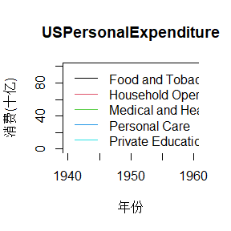

```r
y<-as.numeric(colnames(dt))
plot(y,dt[1,],main="USPersonalExpenditure",xlab="年份",ylab="消费(十亿)",ylim = c(0,100),type = "l")
for (i in 2:5) {
  lines(y,dt[i,],col=i)
}
legend("topleft",row.names(dt),col=1:5,lty=1)
```

2(3).表格

```r
dt
```

```
##                       1940   1945  1950 1955  1960
## Food and Tobacco    22.200 44.500 59.60 73.2 86.80
## Household Operation 10.500 15.500 29.00 36.5 46.20
## Medical and Health   3.530  5.760  9.71 14.0 21.10
## Personal Care        1.040  1.980  2.45  3.4  5.40
## Private Education    0.341  0.974  1.80  2.6  3.64
```

# Question

Exercises 3.4, 3.11, and 3.20 (pages 94-96, Statistical Computating with R).

# Answer

## 3.4:Rayleigh density

由密度函数$f(x)=\frac{x}{\sigma^2}e^{-x^2/(2\sigma^2)},x\ge 0,\sigma>0$， 可得分布函数$F(x)=1-e^{-x^2/(2\sigma^2)},x\ge 0,\sigma>0$， 故$F^{-1}_{X}(u)=\sqrt{-2\sigma^2\log(1-u)}$. 而$U$与$1-U$同分布，故可进一步简化为$F^{-1}_{X}(u)=\sqrt{-2\sigma^2\log(u)}$.

生成n个从Rayleigh density产生的随机数

```r
rrayleigh<-function(n=1000,sigma=1){
  return(sqrt(-2*sigma^2*log(runif(n))))
}
```

生成$\sigma=\frac{1}{4},\frac{1}{2},1,2,4,10$的随机数并作图

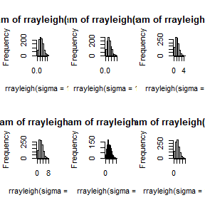

```r
par(mfrow=c(2,3))
hist(rrayleigh(sigma = 1/4))
hist(rrayleigh(sigma = 1/2))
hist(rrayleigh(sigma = 1))
hist(rrayleigh(sigma = 2))
hist(rrayleigh(sigma = 4))
hist(rrayleigh(sigma = 10))
```

上图显示：生成的随机数随$\sigma$变化的规律与密度函数的理论表达一致——$\sigma$越大，随机数取值的跨度越大

## 3.11:bimodal mixture

$p_1=0.75$时模拟柱状图

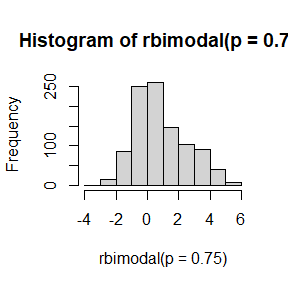

```r
rbimodal<-function(n=1000,p){
  return(rnorm(n,mean = sample(c(0,3),n,replace = T,prob = c(p,1-p))))
}
hist(rbimodal(p=0.75))
```

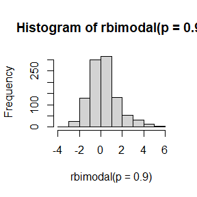

```r
hist(rbimodal(p = 0.9))
```

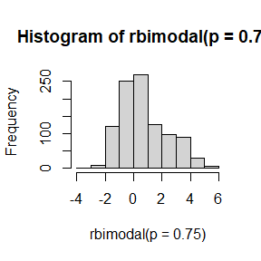

```r
hist(rbimodal(p = 0.75))
```

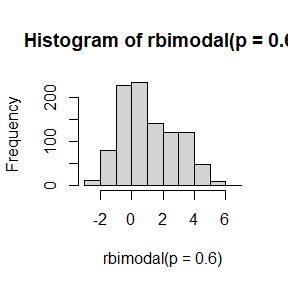

```r
hist(rbimodal(p = 0.6))
```

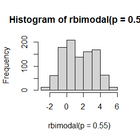

```r
hist(rbimodal(p = 0.55))
```

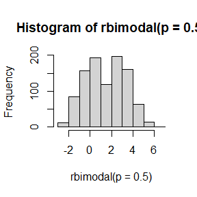

```r
hist(rbimodal(p = 0.5))
```

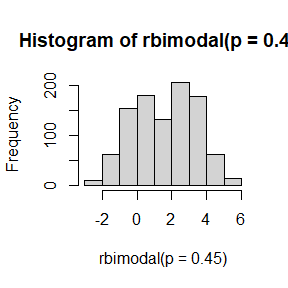

```r
hist(rbimodal(p = 0.45))
```

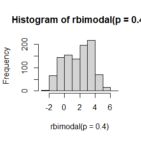

```r
hist(rbimodal(p = 0.4))
```

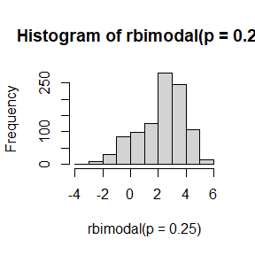

```r
hist(rbimodal(p = 0.25))
```

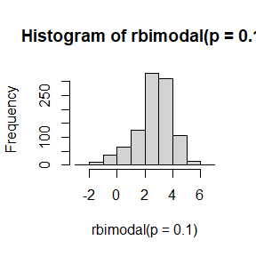

```r
hist(rbimodal(p = 0.1))
```

观察图可知，$p_1=0.6,0.55,0.5,0.45,0.4$时可认为分布是双峰的，其余双峰特征未能显示。

由此可推测：当$p_1$接近0.5时，分布是接近双峰的

## 3.20:Compound Poisson process

根据$N(t)\sim Poisson(\lambda t),Y_i\sim Gamma(a,b),i.i.d,X(t)=\sum_{i=1}^{N(t)}Y_i$，得到的模拟产生混合泊松-伽马过程的方式如下：

```r
rCompoundPoisson<-function(t,n=1,lambda=1,a=1,b=1){
  Nt<-rpois(n,lambda*t)
  X<-rep(0,n)
  for (i in 1:n) {
    X[i]<-sum(rgamma(Nt[i],a,b))
  }
  return(X)
}
```

不同参数对应$X(10)$的模拟均值、方差与理论值的对比

```r
#设定参数
para<-matrix(0,ncol=3,nrow=16)
colnames(para)=c("lambda","a","b")
para[,1]<-c(rep(0.5,4),rep(1,4),rep(2,4),rep(6,4))
para[,2]<-rep(c(0.5,1,1,3),4)
para[,3]<-rep(c(3,3,1,1),4)
#理论值
t<-10
theo<-matrix(0,ncol=2,nrow=16)
colnames(theo)=c("theo-mean","theo-var")
EY<-para[,2]/para[,3]
EY2<-EY^2+para[,2]/(para[,3]^2)
theo[,1]<-para[,1]*t*EY
theo[,2]<-para[,1]*t*EY2
#模拟值
est<-matrix(0,ncol=2,nrow=16)
colnames(est)=c("est-mean","est-var")
for (k in 1:16) {
  x<-rCompoundPoisson(t=10,n=1000,para[k,1],para[k,2],para[k,3])
  est[k,1]<-mean(x)
  est[k,2]<-var(x)
}
#输出结果
res<-cbind(para,est,theo)
#print(res)
knitr::kable(res)
```

| lambda | a | b | est-mean | est-var | theo-mean | theo-var |
| --- | --- | --- | --- | --- | --- | --- |
| 0.5 | 0.5 | 3 | 0.8264205 | 0.4251222 | 0.8333333 | 0.4166667 |
| 0.5 | 1.0 | 3 | 1.6310663 | 1.1203981 | 1.6666667 | 1.1111111 |
| 0.5 | 1.0 | 1 | 4.9244054 | 8.7785099 | 5.0000000 | 10.0000000 |
| 0.5 | 3.0 | 1 | 14.7173811 | 57.8927352 | 15.0000000 | 60.0000000 |
| 1.0 | 0.5 | 3 | 1.7000787 | 0.8508501 | 1.6666667 | 0.8333333 |
| 1.0 | 1.0 | 3 | 3.3443278 | 2.1480201 | 3.3333333 | 2.2222222 |
| 1.0 | 1.0 | 1 | 9.7888402 | 19.6023848 | 10.0000000 | 20.0000000 |
| 1.0 | 3.0 | 1 | 29.5937574 | 109.3656682 | 30.0000000 | 120.0000000 |
| 2.0 | 0.5 | 3 | 3.3059683 | 1.6502224 | 3.3333333 | 1.6666667 |
| 2.0 | 1.0 | 3 | 6.6551014 | 4.5291325 | 6.6666667 | 4.4444444 |
| 2.0 | 1.0 | 1 | 19.8138668 | 40.4536421 | 20.0000000 | 40.0000000 |
| 2.0 | 3.0 | 1 | 59.1264955 | 223.3521656 | 60.0000000 | 240.0000000 |
| 6.0 | 0.5 | 3 | 10.1201241 | 5.1485971 | 10.0000000 | 5.0000000 |
| 6.0 | 1.0 | 3 | 20.0353147 | 13.0531204 | 20.0000000 | 13.3333333 |
| 6.0 | 1.0 | 1 | 59.5962861 | 119.1053218 | 60.0000000 | 120.0000000 |
| 6.0 | 3.0 | 1 | 179.6840153 | 693.7987814 | 180.0000000 | 720.0000000 |

对比表格可知，模拟值与理论值较为接近

# Question

Exercises 5.4, 5.9, 5.13, and 5.14 (pages 149-151, Statistical Computating with R).

# Answer

## 5.4 Beta(3,3)

$Beta(\alpha,\beta)$的cdf：$\phi(x)=\int^x_0\frac{t^{\alpha-1}(1-t)^{\beta-1}}{Beta(\alpha,\beta)}dt$，故题中$Beta(3,3)$的cdf只要计算$\theta=\int^x_0t^2(1-t)^2dt$。

令$y=t/x$，则$dt=xdy$，且$\theta=\int^1_0x^3y^2(1-xy)^2dy=E_Y[x^3Y^2(1-xY)^2]$，其中$Y\sim U(0,1)$。

生成U(0,1)分布的iid：$u_1,u_2,\dots,u_m$，故有$\hat{\theta}=\overline{g_m(x)}=\frac{1}{m}\sum_{i=1}^m x^3u_i^2(1-xu_i)^2$，并可由此得到$\phi(x)$。

```r
x<-seq(0,1,0.1)
m<-1000
u<-runif(m)
cdf<-numeric(length(x))
for (i in 1:length(x)) {
  g<-x[i]^3*u^2*(1-x[i]*u)^2
  cdf[i]<-mean(g)/beta(3,3)
}
Phi<-pbeta(x,3,3)
print(round(rbind(x,cdf,Phi),3))
```

```
##     [,1]  [,2]  [,3]  [,4]  [,5]  [,6]  [,7]  [,8]  [,9] [,10] [,11]
## x      0 0.100 0.200 0.300 0.400 0.500 0.600 0.700 0.800 0.900  1.00
## cdf    0 0.008 0.057 0.160 0.312 0.493 0.676 0.833 0.942 0.997  1.01
## Phi    0 0.009 0.058 0.163 0.317 0.500 0.683 0.837 0.942 0.991  1.00
```

由对比可知，该函数生成的估计值与理论值较为接近。

## 5.9 Antithetic variables

由$f(x)=\frac{x}{\sigma^2}e^{-x^2/(2\sigma^2)},x\ge0,\sigma>0$可知分布函数$F(x)=\int_{-\infty}^xf(t)dt=\int_0^x\frac{t}{\sigma^2}e^{-t^2/(2\sigma^2)}dt=1-e^{-x^2/(2\sigma^2)},x\ge0,\sigma>0$，且分布函数单调递增。

则对符合均匀分布$U(0,1)$的随机变量$U$，$X=F^{-1}(U),X'=F^{-1}(1-U)$为负相关的变量。

以下为以此生成随机数的函数：

```r
rRayleigh<-function(n=1000,sigma=1,anti= TRUE){
  u<-runif(n)
  if (!anti) v<-runif(n) else
    v <- 1-u
  x1<-sqrt(-2*sigma^2*log(u))
  x2<-sqrt(-2*sigma^2*log(v))
  x<-(x1+x2)/2
  return(x)
}
```

方差比较：

```r
K<-100
# 对偶变量的方差
sd_an<-0
for (k in 1:K) {
  sd_an<-sd_an+var(rRayleigh(anti= TRUE))
}
sd_an<-sd_an/K
print(sd_an)
```

```
## [1] 0.01136975
```

```r
# 独立变量的方差
sd_in<-0
for (k in 1:K) {
  sd_in<-sd_in+var(rRayleigh(anti= FALSE))
}
sd_in<-sd_in/K
print(sd_in)
```

```
## [1] 0.2145989
```

```r
# 对比方差减小比例
print((sd_in-sd_an)/sd_in)
```

```
## [1] 0.9470186
```

## 5.13 Importance functions

$\hat{\theta}=\int_1^\infty\frac{x^2}{\sqrt{2\pi}}e^{-x^2/2}dx=\int_0^1\frac{1}{t^4\sqrt{2\pi}}e^{-1/(2t^2)}dt$，对化简后的式子（对$h(t)=\frac{1}{t^4\sqrt{2\pi}}e^{-1/(2t^2)}$积分）进行计算。

取$f_1(x)=1,-\infty<x<+\infty$和$f_2(x)=(1+x^2)^{-1}/\pi,0<x<\infty$

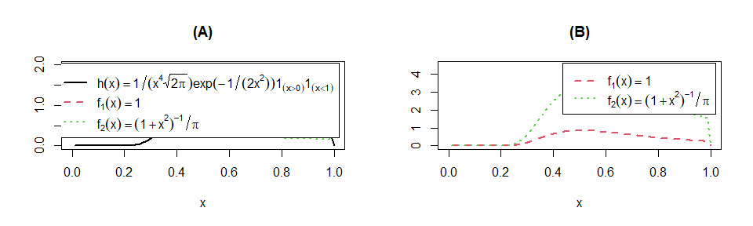

```r
    x <- seq(0, 1, .01)
    w <- 2
    h <- 1/x^4/sqrt(2*pi)*exp(-1/2/x^2) * (x > 0) * (x < 1)
    f1 <- rep(1,length(x))
    f2 <- (1 / pi) / (1 + x^2)
    gs <- c(expression(h(x)==1/(x^4*sqrt(2*pi))*exp(-1/(2*x^2)) *1[(x>0)]* 1[(x < 1)]),
            expression(f[1](x)==1),
            expression(f[2](x)==(1+x^2)^{-1}/pi))
    #for color change lty to col
    par(mfrow=c(1,2))
    #figure (a)
    plot(x, h, type = "l", ylab = "",
         ylim = c(0,2), lwd = w,col=1,main='(A)')
    lines(x, f1, lty = 2, lwd = w,col=2)
    lines(x, f2, lty = 3, lwd = w,col=3)
    legend("topright", legend = gs,
           lty = 1:3, lwd = w, inset = 0.02,col=1:3)

    #figure (b)
    plot(x, h/f1, type = "l", ylab = "",
        ylim = c(0,4.5), lwd = w, lty = 2,col=2,main='(B)')
    lines(x, h/f2, lty = 3, lwd = w,col=3)
    legend("topright", legend = gs[-1],
           lty = 2:3, lwd = w, inset = 0.02,col=2:3)
```

$f_1$的拟合的方差更小。 因为$f_2$有大量取值接近0（如图A），使得$g(x)/f(x)$（如图B）远离0，而且造成较大误差，因此方差较大。

## 5.14 Importance sampling

用$f_1(x)=1,-\infty<x<+\infty$和$f_2(x)=e^{-x},0<x<\infty$两函数进行估计

```r
m <- 10000
theta.hat <- se <- numeric(2)
h <- function(x) {
  1/x^4/sqrt(2*pi)*exp(-1/2/x^2) * (x > 0) * (x < 1)
}
```

```r
# f1
x <- runif(m)
fh <- h(x)
theta.hat[1] <- mean(fh)
se[1] <- sd(fh)
# f2
x <- rexp(m, 1)
fh <- h(x) / exp(-x)
theta.hat[2] <- mean(fh)
se[2] <- sd(fh)
# 结果
rbind(theta.hat,se)
```

```
##                [,1]      [,2]
## theta.hat 0.4005116 0.3922008
## se        0.3048225 0.5399976
```

上述结果中，theta.hat和se分别表示$\hat{\theta}$的用$\frac{h(X_i)}{f(X_i)}$拟合的结果和方差。

# Question

1.Exercises 6.5 and 6.A (page 180-181, Statistical Computating with R).

2.If we obtain the powers for two methods under a particular simulation setting with 10,000 experiments: say, 0.651 for one method and 0.676 for another method. We want to know if the powers are different at 0.05 level.

What is the corresponding hypothesis test problem?

What test should we use? Z-test, two-sample t-test, paired-t test or McNemar test? Why?

Please provide the least necessary information for hypothesis testing.

# Answer

## 6.5

$\chi^2(2)$的理论均值为$\mu=2$

```r
n<-20
alpha<-0.05
CL <- replicate(1000, expr = {
x <- rchisq(n,2)
c(mean(x)+ qt(alpha/2, df=n-1)*sqrt(var(x))/ sqrt(n),mean(x)- qt(alpha/2, df=n-1)*sqrt(var(x))/ sqrt(n))
} )
#compute the mean to get the confidence level
length(intersect(which(CL[1,]<2),which(CL[2,]>2)))/1000
```

```
## [1] 0.905
```

Example6.4中的方差在置信区间中的概率（理论值）为0.95，说明该要求更低，故上述蒙特卡洛方法更稳健。

## 6.A

```r
n <- 20
alpha <- .05
mu0 <- 1
m <- 10000 #number of replicates
p <- numeric(m) #storage for p-values
```

$\chi^2(1)$

```r
for (j in 1:m) {
  x <- rchisq(n, 1)
  ttest <- t.test(x, alternative = "greater", mu = mu0)
  p[j] <- ttest$p.value
}
p.hat <- mean(p < alpha)
se.hat <- sqrt(p.hat * (1 - p.hat) / m)
print(c(p.hat, se.hat))
```

```
## [1] 0.013700000 0.001162425
```

```r
for (j in 1:m) {
  x <- runif(n,0,2)
  ttest <- t.test(x, alternative = "greater", mu = mu0)
  p[j] <- ttest$p.value
}
p.hat <- mean(p < alpha)
se.hat <- sqrt(p.hat * (1 - p.hat) / m)
print(c(p.hat, se.hat))
```

```
## [1] 0.050800000 0.002195891
```

$Exp(1)$

```r
for (j in 1:m) {
  x <- rexp(n, 1)
  ttest <- t.test(x, alternative = "greater", mu = mu0)
  p[j] <- ttest$p.value
}
p.hat <- mean(p < alpha)
se.hat <- sqrt(p.hat * (1 - p.hat) / m)
print(c(p.hat, se.hat))
```

```
## [1] 0.018800000 0.001358181
```

## 2

记两次的power分别为$p_1,p_2$，则假设检验的问题是：$H_0:p_1=p_2,H_1:p_1\neq p_2$。

应该使用McNemar检验。Z检验常用于大样本的平均值差异性检验，用标准正态分布的理论来推断差异发生的概率，从而比较两个平均数的差异是否显著。t检验主要用于样本含量较小），总体标准差未知的正态分布资料,两样本t检验和配对t检验则是根据样本情况和假设检验本身进行选择。McNemar检验用于比较两个模型的差异性，检验统计量是原假设发生的概率，具有卡方分布t特征。

必要信息：二分类形式的变量，所有研究对象均有前后两次数据测量

## Question

Exercises 6.C (pages 182, Statistical Computing with R).

## Answer

### 6.C

Repeat Examples 6.8 and 6.10 for Mardia’s multivariate skewness test. Mardia[187] proposed tests of multivariate normality based on multivariate generalizations of skewness and kurtosis. If $X$ and $Y$ are iid, the multivariate population skewness $\beta_{1,d}$ is defined by Mardia as
$$\beta_{1,d}=E[(X-\mu)^T\Sigma^{-1}(Y-u)]^3.$$
Under normality, $\beta_{1,d}=0$. The multivariate skewness statistic is
$$b_{1,d}=\frac{1}{n^2}\sum_{i,j=1}^n((X_i-\bar X)^T\hat \Sigma^{-1}(X_j-\bar X))^3, \tag{6.5}$$
where $\hat \Sigma$ is the maximum likelihood estimator of covariance. Large values of $b_{1,d}$ are significant. The asymptotic distribution of $nb_{1,d}/6$ is chisquared with $d(d+1)(d+2)/6$ degrees of freedom.

**多元正态性的偏度检验(6.8)：**
假设为
$$H_0:\beta_{1,d}=0 \leftrightarrow H_1:\beta_{1,d}\neq 0$$
当多元总体为正态时，$\frac{nb_{1,d}}{6}$的渐进分布为$\chi_{d(d+1)(d+2)/6}^2$，对大的$|\beta_{1,d}|$值拒绝原假设。
对大小为$n=10,20,30,50,100,500$的样本，估计基于$\frac{nb_{1,d}}{6}$的渐进分布的多元正态性偏度检验在显著水平$\alpha=0.05$下的第一类错误率，在正态极限分布下计算临界值向量并存储到$b_0$中。并给出*mul.sk()*函数用来计算样本多元偏度统计量。

```r
nn <- c(10,20,30,50,100,500)  # 样本容量
alpha <- 0.05                 # 显著性水平
d <- 2                        # 随机变量的维数
b0 <- qchisq(1-alpha,df=d*(d+1)*(d+2)/6)*6/nn  # 每种样本容量临界值向量

# 计算多元样本偏度统计量
mul.sk <- function(x){
  n <- nrow(x) # 样本个数
  xbar <- colMeans(x)
  sigma.hat <- (n-1)/n*cov(x) # MLE估计

  b <- 0
  for(i in 1:nrow(x)){
    for(j in 1:nrow(x)){
      b <- b+((x[i,]-xbar)%*%solve(sigma.hat)%*%(x[j,]-xbar))^3
    }
  }
  return(b/(n^2))
}

# 计算第一类错误的经验估计
library(mvtnorm)
set.seed(200)
p.reject <- vector(mode = "numeric",length = length(nn)) # 保存模拟结果

m <- 100

for(i in 1:length(nn)){
  mul.sktests <- vector(mode = "numeric",length = m)
  for(j in 1:m){
    data <- rmvnorm(nn[i],mean = rep(0,d))
    mul.sktests[j] <- as.integer(mul.sk(data)>b0[i])
  }
  p.reject[i] <- mean(mul.sktests)
}
p.reject
```

```
## [1] 0.00 0.03 0.04 0.03 0.01 0.03
```

模拟结果为第一类错误的经验估计，总结如下:

```r
summ <- rbind(nn,p.reject)
rownames(summ) <- c("n","estimate")
knitr::kable(summ)
```

| n | 10 | 20.00 | 30.00 | 50.00 | 1e+02 | 5e+02 |
| --- | --- | --- | --- | --- | --- | --- |
| estimate | 0 | 0.03 | 0.04 | 0.03 | 1e-02 | 3e-02 |

**多元正态性偏度检验的功效(6.10)**
类似例6.10，针对污染正态备择假设，通过模拟估计多元正态性偏度检验的功效，污染正态分布表示如下：
$$(1-\epsilon)N(0,I_d)+\epsilon N(0,100I_d),0 \leq \epsilon \leq 1$$
对一列以$\epsilon$为指标的备择假设估计其多元偏度检验的功效，并绘制检验功效的功效函数。显著性水平$\alpha=0.1$，样本大小为$n=30$。

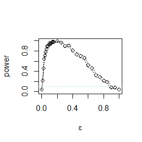

```r
alpha <- 0.1
n <- 30      # 样本大小
m <- 200   # 重复次数
epsilon <- c(seq(0,0.15,0.01),seq(0.15,1,0.05))
N <- length(epsilon)
power <- vector(mode = "numeric",length = N)
b0 <- qchisq(1-alpha,df=d*(d+1)*(d+2)/6)*6/n  #临界值

# 对这列epsilon分别求power
for(j in 1:N){
  e <- epsilon[j]
  mul.sktests <- numeric(m)
  for(i in 1:m){
    # 生成混合分布
    u <- sample(c(1,0),size = n,replace = T,prob = c(1-e,e))
    data1 <- rmvnorm(n,sigma = diag(1,d))
    data2 <- rmvnorm(n,sigma = diag(100,d))
    data <- u*data1+(1-u)*data2
    mul.sktests[i] <- as.integer(mul.sk(data)>b0)
  }
  power[j] <- mean(mul.sktests)
}

# 绘制功效函数
plot(epsilon,power,type="b",xlab=bquote(epsilon),ylim=c(0,1))
abline(h=0.1,lty=3,col="lightblue")
se <- sqrt(power*(1-power)/m)  # 绘制标准误差
lines(epsilon,power-se,lty=3)
lines(epsilon,power+se,lty=3)
```

从图中可以看出，功效函数在两个端点$\epsilon=0$和$\epsilon=1$处与$\alpha=0.1$对应的水平线相较，对于$0<\epsilon<1$，经验功效函数要大于0.1，且在0.15左右达到最高。

# Question

Exercises 7.7,7.8,7.9 and 7.B (pages 213, Statistical Computating with R)

# Answer

## 7.7

sample estimate of $\hat{\theta}$

```r
library(bootstrap)
data("scor",package = "bootstrap")
n<-nrow(scor)
lam.hat<-eigen(cov(scor))$value
theta.hat<-lam.hat[1]/sum(lam.hat)
theta.hat
```

```
## [1] 0.619115
```

Use bootstrap to estimate the bias and standard error of $\hat{\theta}$.

```r
B<-50
theta.b<-numeric(B)
for (b in 1:B) {
  i<-sample(1:n,size = n,replace = TRUE)
  S<-cov(scor[i,])
  lam<-eigen(S)$value
  theta.b[i]<-lam[1]/sum(lam)
}
bias<-mean(theta.b-theta.hat)
bias
```

```
## [1] -0.03244159
```

```r
sd<-sd(theta.b)
sd
```

```
## [1] 0.03027344
```

## 7.8

Obtain the jackknife estimates of bias and standard error of $\hat{\theta}$.

```r
theta.j<-numeric(n)
for (i in 1:n) {
  S<-cov(scor[-i,])
  lam<-eigen(S)$value
  theta.j[i]<-lam[1]/sum(lam)
}
bias<-(n-1)*(mean(theta.j)-theta.hat)
bias
```

```
## [1] 0.001069139
```

```r
se<-sqrt((n-1)*mean((theta.j-mean(theta.j))^2))
se
```

```
## [1] 0.04955231
```

## 7.9

Compute 95% percentile and BCa confidence intervals for $\hat{\theta}$.

```r
library(boot)
theta.boot<-function(dat,ind){
  S<-cov(dat[ind,])
  lam<-eigen(S)$value
  lam[1]/sum(lam)
}
boot.obj<-boot(scor,statistic = theta.boot,R=2000)
print(boot.ci(boot.obj,type = "perc"))
```

```
## BOOTSTRAP CONFIDENCE INTERVAL CALCULATIONS
## Based on 2000 bootstrap replicates
##
## CALL :
## boot.ci(boot.out = boot.obj, type = "perc")
##
## Intervals :
## Level     Percentile
## 95%   ( 0.5239,  0.7079 )
## Calculations and Intervals on Original Scale
```

```r
boot.BCa<-function(x,th0,th,stat,conf=.95){
  x<-as.matrix(x)
  n<-nrow(x)
  N<-1:n
  alpha<-(1+c(-conf,conf))/2
  zalpha<-qnorm(alpha)
  z0<-qnorm(sum(th<th0)/length(th))
  th.jack <- numeric(n)
  for (i in 1:n) {
    J <- N[1:(n-1)]
    th.jack[i] <- stat(x[-i, ], J)
  }
  L <- mean(th.jack) - th.jack
  a <- sum(L^3)/(6 * sum(L^2)^1.5)
  adj.alpha <- pnorm(z0 + (z0+zalpha)/(1-a*(z0+zalpha)))
  limits <- quantile(th, adj.alpha, type=6)
  return(list("est"=th0, "BCa"=limits))
}
boot.BCa(scor,th0<-theta.hat,th=theta.b,stat=theta.boot)
```

```
## $est
## [1] 0.619115
##
## $BCa
## 23.71444% 99.95263%
## 0.5713739 0.6315652
```

## 7.B

normal populations (skewness 0)

```r
library(boot)
n<-10000
x<-rnorm(n)
theta.boot<-function(dat,ind){
  mean(dat[ind])
}
boot.obj<-boot(x,statistic = theta.boot,R=2000)
ci<-boot.ci(boot.obj,type = c("norm","basic","perc"))
print(ci)
```

```
## BOOTSTRAP CONFIDENCE INTERVAL CALCULATIONS
## Based on 2000 bootstrap replicates
##
## CALL :
## boot.ci(boot.out = boot.obj, type = c("norm", "basic", "perc"))
##
## Intervals :
## Level      Normal              Basic              Percentile
## 95%   (-0.0200,  0.0203 )   (-0.0202,  0.0199 )   (-0.0196,  0.0205 )
## Calculations and Intervals on Original Scale
```

```r
intervals<-matrix(0,nrow = 3,ncol = 2)
intervals[1,]<-ci$normal[-1]
intervals[2,]<-ci$basic[-3:-1]
intervals[3,]<-ci$percent[-3:-1]
```

```r
M<-1000
mont.mean<-numeric(M)
for (i in 1:M) {
  xm<-rnorm(n)
  mont.mean[i]<-mean(xm)
}
cover<-rep(0,3)
left<-rep(0,3)
right<-rep(0,3)
```

```r
for (j in 1:3) {
  left.id<-which(mont.mean<intervals[j,1])
  right.id<-which(mont.mean>intervals[j,2])
  left[j]<-length(left.id)
  right[j]<-length(right.id)
  cover[j]<-M-left[j]-right[j]
}
cover/M # empirical coverage rates for the sample mean
```

```
## [1] 0.942 0.941 0.940
```

```r
left/M #proportion of times that the confidence intervals miss on the left
```

```
## [1] 0.030 0.028 0.033
```

```r
right/M #porportion of times that the confidence intervals miss on the right
```

```
## [1] 0.028 0.031 0.027
```

$\chi^2(5)$ distributions (positive skewness)

```r
library(boot)
n<-10000
x<-rchisq(n,5)
theta.boot<-function(dat,ind){
  mean(dat[ind])
}
boot.obj<-boot(x,statistic = theta.boot,R=2000)
ci<-boot.ci(boot.obj,type = c("norm","basic","perc"))
print(ci)
```

```
## BOOTSTRAP CONFIDENCE INTERVAL CALCULATIONS
## Based on 2000 bootstrap replicates
##
## CALL :
## boot.ci(boot.out = boot.obj, type = c("norm", "basic", "perc"))
##
## Intervals :
## Level      Normal              Basic              Percentile
## 95%   ( 4.881,  5.001 )   ( 4.882,  4.999 )   ( 4.884,  5.002 )
## Calculations and Intervals on Original Scale
```

```r
intervals<-matrix(0,nrow = 3,ncol = 2)
intervals[1,]<-ci$normal[-1]
intervals[2,]<-ci$basic[-3:-1]
intervals[3,]<-ci$percent[-3:-1]
```

```r
M<-1000
mont.mean<-numeric(M)
for (i in 1:M) {
  xm<-rchisq(n,5)
  mont.mean[i]<-mean(xm)
}
cover<-rep(0,3)
left<-rep(0,3)
right<-rep(0,3)
```

```r
for (j in 1:3) {
  left.id<-which(mont.mean<intervals[j,1])
  right.id<-which(mont.mean>intervals[j,2])
  left[j]<-length(left.id)
  right[j]<-length(right.id)
  cover[j]<-M-left[j]-right[j]
}
cover/M # empirical coverage rates for the sample mean
```

```
## [1] 0.530 0.514 0.540
```

```r
left/M #proportion of times that the confidence intervals miss on the left
```

```
## [1] 0.001 0.001 0.001
```

```r
right/M #porportion of times that the confidence intervals miss on the right
```

```
## [1] 0.469 0.485 0.459
```

The coverage rates for normal populations (skewness 0) is bigger than that for $\chi^2(5)$ distributions(positive skewness).

# Question

1.Exercise 8.2 (page 242, Statistical Computating with R).

2.Design experiments for evaluating the performance of the NN, energy, and ball methods in various situations.

- Unequal variances and equal expectations
- Unequal variances and unequal expectations
- Non-normal distributions: t distribution with 1 df (heavy-tailed distribution), bimodel distribution (mixture of two normal distributions)
- Unbalanced samples (say, 1 case versus 10 controls)
- Note: The parameters should be chosen such that the powers are distinguishable (say, range from 0.3 to 0.8).

# Answer

## Exercise 8.2

Implement the bivariate Spearman rank correlation test for independence as a permutation test. The Spearman rank correlation test statistic can be obtained from function $cor$ with $method = "spearman"$. Compare the achieved significance level of the permutation test with the p-value reported by cor.test on the same samples.

使用两组随机生成的数据

```r
n<-20
x<-sample(1:50,n)
y<-sample(1:50,n)
```

```r
R <- 999 #number of replicates
z <- c(x, y) #pooled sample
K <- n*2
set.seed(0)
reps <- numeric(R) #storage for replicates
t0 <- cor(x,y,method = "spearman")
for (i in 1:R) {
#generate indices k for the first sample
k <- sample(K, size = n, replace = FALSE)
x1 <- z[k]
y1 <- z[-k] #complement of x1
reps[i] <- cor(x1, y1,method = "spearman")
}
p <- mean(abs(c(t0, reps)) >= abs(t0))

round(c(p,cor.test(x,y,method = "spearman")$p.value),3)
```

```
## [1] 0.863 0.866
```

两种方法得到的p-值较为接近。

若两组数据相关性较高（y=2x）

```r
n<-20
x<-sample(1:50,n)
y<-x*2
```

```r
R <- 999 #number of replicates
z <- c(x, y) #pooled sample
K <- n*2
set.seed(0)
reps <- numeric(R) #storage for replicates
t0 <- cor(x,y,method = "spearman")
for (i in 1:R) {
#generate indices k for the first sample
k <- sample(K, size = n, replace = FALSE)
x1 <- z[k]
y1 <- z[-k] #complement of x1
reps[i] <- cor(x1, y1,method = "spearman")
}
p <- mean(abs(c(t0, reps)) >= abs(t0))

round(c(p,cor.test(x,y,method = "spearman")$p.value),3)
```

```
## [1] 0.001 0.000
```

两种方法得到的p-值较为接近。

## Designing experiments

```r
library(RANN)
library(boot)
library(energy)
library(Ball)
Tn <- function(z, ix, sizes,k) {
  n1 <- sizes[1]
  n2 <- sizes[2]
  n <- n1 + n2
  if(is.vector(z)) z <- data.frame(z,0)
  z <- z[ix, ]
  NN <- nn2(data=z, k=k+1)
  block1 <- NN$nn.idx[1:n1,-1]
  block2 <- NN$nn.idx[(n1+1):n,-1]
  i1 <- sum(block1 < n1 +.5)
  i2 <- sum(block2 > n1+.5)
  (i1+i2) / (k*n)
}
eqdist.nn <- function(z,sizes,k){
  boot.obj <- boot(data=z,statistic=Tn,R=R,
  sim = "permutation", sizes = sizes,k=k)
  ts <- c(boot.obj$t0,boot.obj$t)
  p.value <- mean(ts>=ts[1])
  list(statistic=ts[1],p.value=p.value)
}
```

- Unequal variances and equal expectations

```r
m <- 1000
k<-3
R<-99
set.seed(12345)
n1 <- n2 <- 100
n <- n1+n2
N = c(n1,n2)
```

```r
p.values <- matrix(NA,m,3)
for(i in 1:m){
  x <- rnorm(n1,0,1)
  y <- rnorm(n2,0,1.4)
  z <- c(x,y)
  p.values[i,1] <- eqdist.nn(z,N,k)$p.value
  p.values[i,2] <- eqdist.etest(z,sizes=N,R=R)$p.value
  p.values[i,3] <- bd.test(x=x,y=y,num.permutations=99,seed=i*12345)$p.value
}
alpha <- 0.1;
pow <- colMeans(p.values<alpha)
pow
```

```
## [1] 0.288 0.503 0.709
```

“ball” performs best

```r
p.values <- matrix(NA,m,3)
for(i in 1:m){
  x <- rnorm(n1,0,1)
  y <- rnorm(n2,1/3,1)
  z <- c(x,y)
  p.values[i,1] <- eqdist.nn(z,N,k)$p.value
  p.values[i,2] <- eqdist.etest(z,sizes=N,R=R)$p.value
  p.values[i,3] <- bd.test(x=x,y=y,num.permutations=99,seed=i*12345)$p.value
}
alpha <- 0.1;
pow <- colMeans(p.values<alpha)
pow
```

```
## [1] 0.199 0.718 0.550
```

“energy” performs best

- Non-normal distributions: t distribution with 1 df (heavy-tailed distribution), bimodel distribution (mixture of two normal distributions)

t distribution

```r
p.values <- matrix(NA,m,3)
for(i in 1:m){
  x <- rt(n1,1)
  y <- rt(n2,2)
  z <- c(x,y)
  p.values[i,1] <- eqdist.nn(z,N,k)$p.value
  p.values[i,2] <- eqdist.etest(z,sizes=N,R=R)$p.value
  p.values[i,3] <- bd.test(x=x,y=y,num.permutations=99,seed=i*12345)$p.value
}
alpha <- 0.1;
pow <- colMeans(p.values<alpha)
pow
```

```
## [1] 0.194 0.630 0.508
```

“energy” performs best

bimodel distribution

```r
p.values <- matrix(NA,m,3)
for(i in 1:m){
  x <- rnorm(n1,-1,1)+rnorm(n1,1,1)
  y <- rnorm(n2,-1/2,1)+rnorm(n2,1,1)
  z <- c(x,y)
  p.values[i,1] <- eqdist.nn(z,N,k)$p.value
  p.values[i,2] <- eqdist.etest(z,sizes=N,R=R)$p.value
  p.values[i,3] <- bd.test(x=x,y=y,num.permutations=99,seed=i*12345)$p.value
}
alpha <- 0.1;
pow <- colMeans(p.values<alpha)
pow
```

```
## [1] 0.215 0.743 0.581
```

“energy” performs best

- Unbalanced samples (say, 1 case versus 10 controls)

```r
n1 <- 10
n2 <- 20
n <- n1+n2
N = c(n1,n2)
p.values <- matrix(NA,m,3)
for(i in 1:m){
  x <- rnorm(n1,0,1)
  y <- rnorm(n2,0,3)
  z <- c(x,y)
  p.values[i,1] <- eqdist.nn(z,N,k)$p.value
  p.values[i,2] <- eqdist.etest(z,sizes=N,R=R)$p.value
  p.values[i,3] <- bd.test(x=x,y=y,num.permutations=99,seed=i*12345)$p.value
}
alpha <- 0.1;
pow <- colMeans(p.values<alpha)
pow
```

```
## [1] 0.542 0.437 0.868
```

“ball” performs best

# Question

1.Exercies 9.3 and 9.8 (pages 277-278, Statistical Computating with R).

2.For each of the above exercise, use the Gelman-Rubin method to monitor convergence of the chain, and run the chain until it converges approximately to the target distribution according to $\hat{R}<1.2$.

# Answer

## Exercise 9.3

Use the Metropolis-Hastings sampler to generate random variables from a standard Cauchy distribution. Discard the first 1000 of the chain, and compare the deciles of the generated observations with the deciles of the standard Cauchy distribution (see $qcauchy$ or $qt$ with df=1). Recall that a Cauchy($\theta, \eta$) distribution has density function
$$f(x)=\frac{1}{\theta\pi(1+[(x-\eta)/\theta]^2)},-\infty<x<\infty,\theta>0$$
The standard Cauchy has the Cauchy($\theta = 1, \eta = 0$) density. (Note that the standard Cauchy density is equal to the Student t density with one degree of freedom.)

标准柯西分布：$f(x)=\frac{1}{\pi(1+x^2)},-\infty<x<\infty$

```r
f <- function(x) {
  return(1/pi/(1+x^2))
}
m <- 10000
f1<-function(m){
  x <- numeric(m)
  x[1] <- rnorm(1)
  k <- 0
  u <- runif(m)
  for (i in 2:m) {
    xt <- x[i-1]
    y <- rnorm(1)
    num <- f(y) * dnorm(xt)
    den <- f(xt) * dnorm(y)
    if (u[i] <= num/den){
      x[i] <- y
      } else {
        x[i] <- xt
        k <- k+1     #y is rejected
      }
  }
  return(x)
}
set.seed(0)
x<-f1(m)
```

选取部分生成的随机变量如图所示：

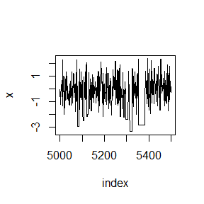

```r
index <- 5000:5500
y1 <- x[index]
plot(index, y1, type="l", main="", ylab="x")
```

比较生成观测值的十分位数和标准柯西分布的十分位数

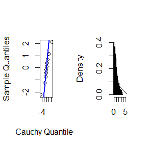

```r
b <- 1001      #discard the burn-in sample
y <- x[b:m]
a <- ppoints(10)

QC <- qcauchy(a)   #quantiles of Cauchy
Q <- quantile(y, a)
par(mfrow=c(1,2))
    qqplot(QC, Q, main="",
        xlab="Cauchy Quantiles", ylab="Sample Quantiles")
    abline(c(0,0),c(1,1),col='blue',lwd=2)
    hist(y, breaks="scott", main="", xlab="", freq=FALSE,xlim = c(0,5))
    lines(QC, f(QC))
```

Gelman-Rubin method 考查收敛性：

Gelman-Rubin statistic: $\sqrt{\hat R}=\sqrt{\frac{\widehat{var}(\phi)}{W_n}}$

```r
Gelman.Rubin <- function(psi) {
  psi <- as.matrix(psi)
  n <- ncol(psi)
  k <- nrow(psi)
  psi.means <- rowMeans(psi)     #row means
  B <- n * var(psi.means)        #between variance est.
  psi.w <- apply(psi, 1, "var")  #within variances
  W <- mean(psi.w)               #within est.
  v.hat <- W*(n-1)/n + (B/n)     #upper variance est.
  r.hat <- v.hat / W             #G-R statistic
  return(r.hat)
}
```

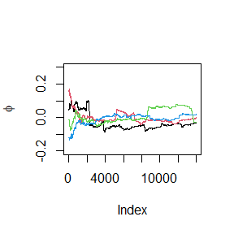

```r
#generate the chains
m<-15000
k<-4
X <- matrix(0, nrow=k, ncol=m)
for (i in 1:k) {
  set.seed(i*12345)
  X[i, ] <- f1(m)
}
psi <- t(apply(X, 1, cumsum))
for (i in 1:nrow(psi)) psi[i,] <- psi[i,] / (1:ncol(psi))
for (i in 1:k){
   if(i==1){
      plot(1:(m-b+1),psi[i,b:m],ylim=c(-0.2,0.3), type="l", xlab='Index', ylab=bquote(phi))
    }else{
      lines(psi[i, b:m], col=i)
    }
}
```

```r
par(mfrow=c(1,1)) #restore default
```

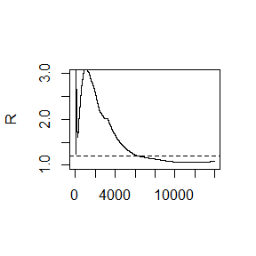

```r
rhat <- rep(0,(m-b+1))
for (j in 1:(m-b+1))  rhat[j] <- Gelman.Rubin(psi[,1:j])
plot(rhat, type="l", xlab="", ylab="R",ylim = c(1,3))
abline(h=1.2, lty=2)
```

如图大约在7000以后即可使得$\hat{R}<1.2$.

## Exercise 9.8

Consider the bivariate density
$$f(x,y)\propto { n \choose x }y^{x+a-1}(1-y)^{n-x+b-1},\quad x=0,1,\dots,n,0\le y\le 1.$$
It can be shown that for fixed $a, b, n$, the conditional distributions are Binomial(n, y) and Beta(x + a, n − x + b). Use the Gibbs sampler to generate a chain with target joint density $f(x, y)$.

取$a=b=2,n=10$，

```r
#initialize constants and parameters
N <- 5000 #length of chain
burn <- 1000 #burn-in length
f2<-function(m,a=2,b=2,n=10){
  X <- matrix(0, m, 2) #the chain, a bivariate sample
  ###### generate the chain #####
  X[1, ] <- c(1, .5) #initialize
  for (i in 2:m) {
    y <- X[i-1, 2]
    X[i, 1] <- rbinom(1, n, y)
    x <- X[i, 1]
    X[i, 2] <- rbeta(1,x+a,n-x+b)
    }
  b <- burn + 1
  return(X[b:m, ])
}
x<-f2(N)
cat('Means: ',round(colMeans(x),2))
```

```
## Means:  4.86 0.49
```

```r
cat('Standard errors: ',round(apply(x,2,sd),2))
```

```
## Standard errors:  2.69 0.23
```

```r
cat('Correlation coefficients: ', round(cor(x[,1],x[,2]),2))
```

```
## Correlation coefficients:  0.84
```

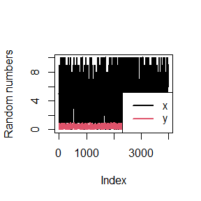

```r
plot(x[,1],type='l',col=1,lwd=2,xlab='Index',ylab='Random numbers')
lines(x[,2],col=2,lwd=2)
legend('bottomright',c(expression(x),expression(y)),col=1:2,lwd=2)
```

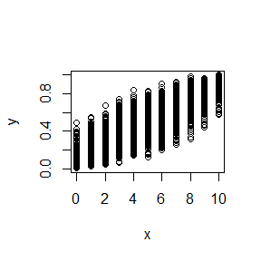

```r
plot(x,xlab='x',ylab='y')
```

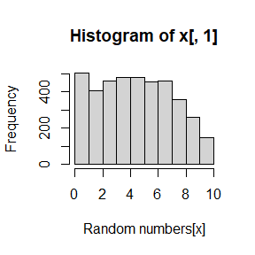

```r
hist(x[,1],xlab='Random numbers[x]')
```

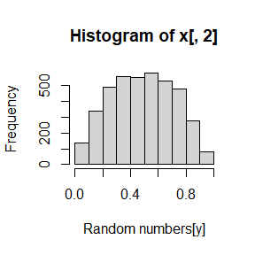

```r
hist(x[,2],xlab='Random numbers[y]')
```

因为抽样结果是二元的，故分开考虑$x,y$的收敛性

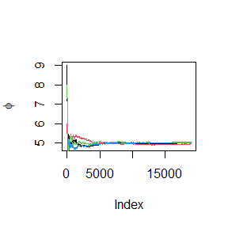

```r
m<-20000
k<-4
X <- matrix(0, nrow=k, ncol=m-b+1)
Y <- matrix(0, nrow=k, ncol=m-b+1)
for (i in 1:k) {
  set.seed(i*123)
  ff<-f2(m)
  X[i, ] <- t(ff[,1])
  Y[i, ] <- t(ff[,2])
}
psi <- t(apply(X, 1, cumsum))
for (i in 1:nrow(psi)) psi[i,] <- psi[i,] / (1:ncol(psi))
for (i in 1:k){
   if(i==1){
      plot(1:(m-b+1),psi[i,], type="l", xlab='Index', ylab=bquote(phi))
    }else{
      lines(psi[i, ], col=i)
    }
}
```

```r
par(mfrow=c(1,1)) #restore default
```

```r
rhat1 <- rep(0,m-b+1)
for (j in 1:(m-b+1))  rhat1[j] <- Gelman.Rubin(psi[,1:j])
```

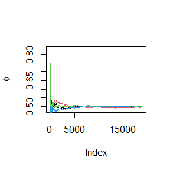

```r
X<-Y
psi <- t(apply(X, 1, cumsum))
for (i in 1:nrow(psi)) psi[i,] <- psi[i,] / (1:ncol(psi))
for (i in 1:k){
   if(i==1){
      plot(1:(m-b+1),psi[i,], type="l", xlab='Index', ylab=bquote(phi))
    }else{
      lines(psi[i, ], col=i)
    }
}
```

```r
par(mfrow=c(1,1))
```

```r
rhat2 <- rep(0,m-b+1)
for (j in 1:(m-b+1))  rhat2[j] <- Gelman.Rubin(psi[,1:j])
```

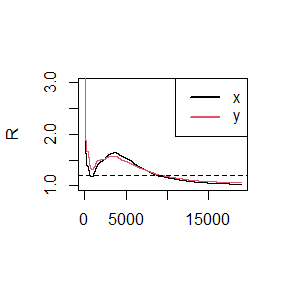

```r
plot(rhat1, type="l", xlab="", ylab="R",ylim = c(1,3))
lines(rhat2,col=2)
abline(h=1.2, lty=2)
legend('topright',c(expression(x),expression(y)),col=1:2,lwd=2)
```

如图大约在10000以后即可使得$\hat{R}<1.2$.

# Question

1.Exercises 11.3 and 11.5 (pages 353-354, Statistical Computing with R)

2.Suppose $T_1,\cdots,T_n$ are i.i.d. samples drawn from the exponential distribution with expectation $\lambda$. Those values greater than $\tau$ are not observed due to right censorship, so that the observed values are $Y_i = T_iI(T_i ≤ \tau ) + \tau I(T_i > \tau ), i = 1,\cdots, n$. Suppose $\tau = 1$ and the observed $Y_i$ values are as follows:
$$0.54, 0.48, 0.33, 0.43, 1.00, 1.00, 0.91, 1.00, 0.21, 0.85$$
Use the E-M algorithm to estimate $\lambda$, compare your result with the observed data MLE (note: $Y_i$ follows a mixture distribution)

# Answer

## Exercise 11.3

(a)计算第k项的函数

```r
fk<-function(a,k){
  d<-length(a)
  rk<-(-1)^k/factorial(k)/(2^k)*(sum(a^2))^(k+1)/(2*k+1)/(2*k+2)*gamma((d+1)/2)*gamma(k+3/2)/gamma(k+d/2+1)
  return(rk)
}
a<-rep(1,5)
fk(a,1)
```

```
## [1] -0.2380952
```

```r
fk(a,2)
```

```
## [1] 0.06613757
```

```r
fk(a,3)
```

```
## [1] -0.01878908
```

```r
fk(a,4)
```

```
## [1] 0.005058599
```

```r
fk(a,5)
```

```
## [1] -0.00126465
```

(b)求和函数

```r
f<-function(a){
  r<-0
  for (i in 1:20) {
    if(abs(fk(a,i))>10^(-5))r<-r+fk(a,i) else break
  }
  return(round(r,5))
}
f(rep(1,5))
```

```
## [1] -0.18671
```

```r
f(c(1,2,3))
```

```
## [1] -1.64224
```

```r
f(rnorm(10))
```

```
## [1] -0.31928
```

(c)$a=(1,2)^T$

```r
a<-c(1,2)
f(a)
```

```
## [1] -0.43134
```

## Exercise 11.5

```r
g0<-function(u,k=4){
  (1+u^2/(k-1))^(-k/2)
}

gleft<-function(a,k=4){
  2*gamma(k/2)/sqrt(pi*(k-1))/gamma((k-1)/2)*integrate(g0,lower = 0,upper = sqrt(a^2*(k-1)/(k-a^2)))$value
}
```

```r
k0<-c(4:25,100)
res<-vector(length = 0)
for (k in k0) {
  g<-function(a){
   gleft(a,k)-gleft(a,k+1)
  }
  solution<-uniroot(g,lower = 0.1,upper = 2)
  res[as.character(k)]<-round(unlist(solution),5)

}
res
```

```
##       4       5       6       7       8       9      10      11      12      13
## 1.34561 1.36121 1.37111 1.37793 1.38287 1.38667 1.38962 1.39199 1.39396 1.39557
##      14      15      16      17      18      19      20      21      22      23
## 1.39696 1.39815 1.39918 1.40008 1.40088 1.40159 1.40223 1.40280 1.40332 1.40379
##      24      25     100
## 1.40423 1.40462 1.41153
```

因为$k=500,1000$时，$\Gamma(k)$过大，无法计算。显然，我们考虑的是a的正数解，由对称性，上述结果的相反数也是a的解。

与11.4对比

```r
S<-function(a,k){
  1-pt(sqrt(a^2*k/(k+1-a^2)),k)
}
k0<-c(4:25,100,500,1000)
res0<-vector(length = 0)
for (k in k0) {
  SS<-function(a){
  S(a,k)-S(a,k-1)
  }
  solution<-uniroot(SS,lower = 0.1,upper = 2)
  res0[as.character(k)]<-round(unlist(solution),5)

}
rbind(res0,c(res,0,0))
```

```
##            4       5       6       7       8       9      10      11      12
## res0 1.49210 1.53356 1.56276 1.58441 1.60119 1.61452 1.62539 1.63441 1.64203
##      1.34561 1.36121 1.37111 1.37793 1.38287 1.38667 1.38962 1.39199 1.39396
##           13      14      15      16      17      18      19      20      21
## res0 1.64854 1.65418 1.65910 1.66344 1.66730 1.67074 1.67383 1.67663 1.67917
##      1.39557 1.39696 1.39815 1.39918 1.40008 1.40088 1.40159 1.40223 1.40280
##           22      23      24      25     100     500    1000
## res0 1.68149 1.68362 1.68557 1.68737 1.72061 1.72975 1.73091
##      1.40332 1.40379 1.40423 1.40462 1.41153 0.00000 0.00000
```

两种方式计算结果有误差，但是随着k的变化趋势是保持一致的.

## Addition

EM方法：

E-step:$E_{\lambda}[X^{(m)}]=\int_1^{+\infty}xP(X=x|X\ge1)dx=\int_1^{+\infty}xe^{\lambda}f(x)I_{(x\ge1)}dx=1+\frac{1}{\lambda}$

M-step:$L(\theta;X^{(0)},X^{(m)})=\prod^{n_1}_{i=1}(\lambda e^{-\lambda x^{(0)}_i})\prod^{n_2}_{j=1}(\lambda e^{-\lambda x^{(m)}_j})=\lambda^nexp(-\lambda(\sum_{i=1}^{n_1}x^{(0)}_i+\sum_{j=1}^{n_2}x^{(m)}_j))$

$\frac{\partial\log L(\lambda)}{\partial\lambda}=\frac{n}{\lambda}-(\sum_{i=1}^{n_1}x^{(0)}_i+\sum_{j=1}^{n_2}x^{(m)}_j)$

$\hat{\lambda}=\frac{n}{\sum_{i=1}^{n_1}x^{(0)}_i+\sum_{j=1}^{n_2}x^{(m)}_j}$

```r
N<-20
l<-rep(2,N)
x0<-c(0.54, 0.48, 0.33, 0.43,  0.91,  0.21, 0.85)
n1<-7
n2<-3
n<-10
eme<-function(la){
  return(1+1/la)
}
emm<-function(xm){
  return(n/(sum(x0)+sum(xm)))
}
for (k in 1:N) {
  xm<-eme(rep(l[k],n2))
  l[k+1]<-emm(xm)
  if(abs(l[k+1]-l[k])<10^(-5))break
}
l[1:(k+1)]#收敛过程
```

```
##  [1] 2.000000 1.212121 1.084011 1.050696 1.041097 1.038252 1.037401 1.037146
##  [9] 1.037070 1.037047 1.037040
```

```r
l[k+1]#EM方法结果
```

```
## [1] 1.03704
```

MLE方法：

$L(\theta)=\prod^{n_1}_{i=1}(\lambda e^{-\lambda x^{(0)}_i})\prod^{n_2}_{j=1}P(T_j>1)=\lambda^{n_1}exp(-\lambda(\sum_{i=1}^{n_1}x^{(0)}_i+n_2))$

$\frac{\partial\log L(\lambda)}{\partial\lambda}=\frac{n_1}{\lambda}-(\sum_{i=1}^{n_1}x^{(0)}_i+m_2)$

$\hat{\lambda}=\frac{n_1}{\sum_{i=1}^{n_1}x^{(0)}_i+n_2}$

```r
n1/(sum(x0)+n2)
```

```
## [1] 1.037037
```

对比：

EM和MLE两种方法得到结果基本一致。

# Question

1.Exercises 1 and 5 (page 204, Advanced R)

2.Excecises 1 and 7 (page 214, Advanced R)

# Answer

## page 204 Exercise 1

Why are the following two invocations of $lapply()$ equivalent?

```r
trims<-c(0,0.1,0.2,0.5)
x <- rcauchy(100)
lapply(trims, function(trim) mean(x, trim = trim))
```

```
## [[1]]
## [1] -0.8266766
##
## [[2]]
## [1] -0.3311811
##
## [[3]]
## [1] -0.3296715
##
## [[4]]
## [1] -0.1091591
```

```r
lapply(trims, mean, x = x)
```

```
## [[1]]
## [1] -0.8266766
##
## [[2]]
## [1] -0.3311811
##
## [[3]]
## [1] -0.3296715
##
## [[4]]
## [1] -0.1091591
```

第一条命令是指：对$trims$向量中元素一一作用函数，函数定义为输出切除trim值的x的均值。

第二条命令是指：对$trims$向量中元素一一作用函数$mean$，而$mean$的参数$x=x$，$trims$中元素则作为$mean$的第二个参数$trim$。

## page 204 Exercise 5

For each model in the previous two exercises, extract $R^2$ using the function below.

```r
rsq <- function(mod) summary(mod)$r.squared
```

第3题的模型：

```r
formulas <- list(
  mpg ~ disp,
  mpg ~ I(1 / disp),
  mpg ~ disp + wt,
  mpg ~ I(1 / disp) + wt
)
```

```r
mod1<-lapply(formulas,lm,data= mtcars)
lapply(mod1, rsq)
```

```
## [[1]]
## [1] 0.7183433
##
## [[2]]
## [1] 0.8596865
##
## [[3]]
## [1] 0.7809306
##
## [[4]]
## [1] 0.8838038
```

第4题的模型：

```r
bootstraps <- lapply(1:10, function(i) {
rows <- sample(1:nrow(mtcars), rep = TRUE)
mtcars[rows, ]
})
```

```r
mod2<-lapply(bootstraps,lm,formula = mpg ~ disp)
lapply(mod2, rsq)
```

```
## [[1]]
## [1] 0.6382452
##
## [[2]]
## [1] 0.6304606
##
## [[3]]
## [1] 0.7978048
##
## [[4]]
## [1] 0.704896
##
## [[5]]
## [1] 0.7352706
##
## [[6]]
## [1] 0.724599
##
## [[7]]
## [1] 0.6745447
##
## [[8]]
## [1] 0.7349265
##
## [[9]]
## [1] 0.7225768
##
## [[10]]
## [1] 0.7788106
```

## page 214 Exercise 1

Use $vapply()$ to:

- 1. Compute the standard deviation of every column in a numeric data frame.

```r
dt<-matrix(sample(1:100),nrow = 20)
df<-data.frame(dt)#一个20*5的numeric data frame
df
```

```
##    X1 X2 X3 X4  X5
## 1  82 97 34 72  78
## 2   5  4 26 13  39
## 3  52 23 10 70  76
## 4  79 25 57 29  99
## 5  33 11 74 59   8
## 6   3 73 46 64  92
## 7  68 15 89 71  48
## 8  41 20  9 24  65
## 9  67 87 47 66  19
## 10 62 98 80 91  50
## 11 84 45 30 94  51
## 12 88 31 60 12  81
## 13 49 18 36 28   2
## 14 83 96 14 86  32
## 15 21 40 42 17 100
## 16 27 63  7 56  90
## 17 54 95 53 55  16
## 18 69 58 61 43  22
## 19 93 77 35 38  44
## 20 75  6 85  1  37
```

```r
vapply(df,sd,FUN.VALUE=0)
```

```
##       X1       X2       X3       X4       X5
## 27.36666 34.07407 25.25423 28.02532 31.13210
```

- 2. Compute the standard deviation of every numeric column in a mixed data frame. (Hint: you’ll need to use $vapply()$ twice.)

```r
dff<-cbind(df,rep("a",20),df+4,rep("b",20))
colnames(dff)<-as.character(1:12) #一个20*12的mixed data frame
dff
```

```
##     1  2  3  4   5 6  7   8  9 10  11 12
## 1  82 97 34 72  78 a 86 101 38 76  82  b
## 2   5  4 26 13  39 a  9   8 30 17  43  b
## 3  52 23 10 70  76 a 56  27 14 74  80  b
## 4  79 25 57 29  99 a 83  29 61 33 103  b
## 5  33 11 74 59   8 a 37  15 78 63  12  b
## 6   3 73 46 64  92 a  7  77 50 68  96  b
## 7  68 15 89 71  48 a 72  19 93 75  52  b
## 8  41 20  9 24  65 a 45  24 13 28  69  b
## 9  67 87 47 66  19 a 71  91 51 70  23  b
## 10 62 98 80 91  50 a 66 102 84 95  54  b
## 11 84 45 30 94  51 a 88  49 34 98  55  b
## 12 88 31 60 12  81 a 92  35 64 16  85  b
## 13 49 18 36 28   2 a 53  22 40 32   6  b
## 14 83 96 14 86  32 a 87 100 18 90  36  b
## 15 21 40 42 17 100 a 25  44 46 21 104  b
## 16 27 63  7 56  90 a 31  67 11 60  94  b
## 17 54 95 53 55  16 a 58  99 57 59  20  b
## 18 69 58 61 43  22 a 73  62 65 47  26  b
## 19 93 77 35 38  44 a 97  81 39 42  48  b
## 20 75  6 85  1  37 a 79  10 89  5  41  b
```

```r
id<-vapply(dff, is.numeric, FUN.VALUE = 1)#判断
vapply(dff[id],sd,FUN.VALUE=0)
```

```
##        1      1.1      1.2      1.3      1.4      1.5      1.6      1.7
## 27.36666 27.36666 27.36666 27.36666 27.36666 27.36666 27.36666 27.36666
##      1.8      1.9
## 27.36666 27.36666
```

## page 214 Exercise 7

Implement $mcsapply()$, a multicore version of $sapply()$. Can you implement $mcvapply()$, a parallel version of $vapply()$? Why or why not?

```r
library(parallel)
mcsapply<-function(X, FUN, ...,mc.cores = 1L, simplify=TRUE, USE.NAMES = TRUE){
  makeCluster(getOption("cl.cores",mc.cores))->cl
  mcl<-parLapply(cl,X,FUN,mc.cores = mc.cores)
  if(simplify==TRUE) mcl<-unlist(mcl)
  if(USE.NAMES==FALSE) row.names(mcl)<-NULL
  return(mcl)
}
#参数取值对比
mcsapply(df,mean)
```

```
##    X1    X2    X3    X4    X5
## 56.75 49.10 44.75 49.45 52.45
```

```r
mcsapply(df,mean,simplify=FALSE)
```

```
## $X1
## [1] 56.75
##
## $X2
## [1] 49.1
##
## $X3
## [1] 44.75
##
## $X4
## [1] 49.45
##
## $X5
## [1] 52.45
```

```r
mcsapply(df,mean,USE.NAMES = FALSE)
```

```
##    X1    X2    X3    X4    X5
## 56.75 49.10 44.75 49.45 52.45
```

```r
#时间对比
system.time(mcsapply(df,mean))
```

```
## 用户 系统 流逝
## 0.00 0.05 0.41
```

```r
system.time(mcsapply(df,mean,mc.cores = 2))
```

```
## 用户 系统 流逝
## 0.00 0.03 0.45
```

```r
system.time(mcsapply(df,mean,mc.cores = 4))
```

```
## 用户 系统 流逝
## 0.00 0.05 0.69
```

```r
system.time(mcsapply(df,mean,mc.cores = 8))
```

```
## 用户 系统 流逝
## 0.01 0.14 1.41
```

$vapply$类似于$sapply$，提供了FUN.VALUE参数，用来控制返回值的行名，这样可以让程序更健壮。在多核运算中，得到的结果无法使用FUN.VALUE参数固定返回值，所以不能得到$mcvapply$

## Question1

Write an Rcpp function for Exercise 9.8 (page 278, Statistical Computing with R).

Consider the bivariate density
$$f(x,y)\propto \binom{n}{x}y^{x+a-1}(1-y)^{n-x+b-1},x=0,1,\dots,n,0\le y\le1.$$
It can be shown that for fixed $a, b, n$, the conditional distributions are Binomial($n, y$) and Beta($x + a, n − x + b$). Use the Gibbs sampler to generate a chain with target joint density $f(x, y)$.

## Answer1

```r
library(Rcpp)
cppFunction('
NumericMatrix gibbsc(int N,int burn,int a,int b,int n){
  NumericMatrix X(N,2);
  NumericMatrix XX(N-burn,2);
  float x,y;
  X(0,0)=1;
  X(0,1)=0.5;
  for(int i=1;i<N;i++){
    y=X(i-1,1);
    X(i,0)=rbinom(1,n,y)[0];
    x=X(i,0);
    X(i,1)=rbeta(1,x+a,n-x+b)[0];
  }
  for(int k=0;k<N-burn;k++){
    XX(k,0)=X(k+burn,0);
    XX(k,1)=X(k+burn,1);
  }
  return XX;
}
')
res1<-gibbsc(5000,1000,2,2,10)
```

## Question2

Compare the corresponding generated random numbers with pure R language using the function “qqplot”.

## Answer2

```r
gibbsr<-function(N,burn,a=2,b=2,n=10){
  X <- matrix(0, N, 2) #the chain, a bivariate sample
  ###### generate the chain #####
  X[1, ] <- c(1, .5) #initialize
  for (i in 2:N) {
    y <- X[i-1, 2]
    X[i, 1] <- rbinom(1, n, y)
    x <- X[i, 1]
    X[i, 2] <- rbeta(1,x+a,n-x+b)
    }
  b <- burn + 1
  return(X[b:N, ])
}
res2<-gibbsr(5000,1000,2,2,10)
```

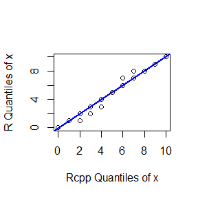

```r
a <- ppoints(50)
Q1x <- quantile(res1[,1], a)   #quantiles of Cauchy
Q2x <- quantile(res2[,1], a)
Q1y <- quantile(res1[,2], a)   #quantiles of Cauchy
Q2y <- quantile(res2[,2], a)
qqplot(Q1x, Q2x, main="",
        xlab="Rcpp Quantiles of x", ylab="R Quantiles of x")
    abline(c(0,0),c(1,1),col='blue',lwd=2)
```

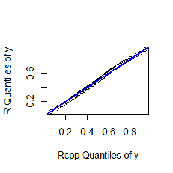

```r
qqplot(Q1y, Q2y, main="",
        xlab="Rcpp Quantiles of y", ylab="R Quantiles of y")
    abline(c(0,0),c(1,1),col='blue',lwd=2)
```

根据Q-Q图可知两种方法得到的采样结果基本一致。

## Question3

Campare the computation time of the two functions with the function “microbenchmark”.

## Answer3

```r
library(microbenchmark)
ts <- microbenchmark(Rcpp=gibbsc(5000,1000,2,2,10),R=gibbsr(5000,1000,2,2,10))
summary(ts)[,c(1,3,5,6)]
```

```
##   expr       lq   median       uq
## 1 Rcpp  2.09875  2.14205  2.27105
## 2    R 24.50800 25.73715 31.22405
```

由表格对比可知，Rcpp中的函数运行速度比R中函数更快。

## Question4

Comments your results.

## Answer4

通过用Rcpp和R中的函数完成Gibbs采样，对比采样结果和运行时间：两种方法的采样结果基本一致，Rcpp中的运行时间明显小于R中时间，具有更高的效率。但在编程过程中，Rcpp需要一些时间来构建cpp，因此如果是少量运算，R更有简易操作，如果是大量运算则采用Rcpp可以有效提高效率。